# Risk Factor Analysis

## Outcome Variable

**Outcome Variable:** haz

## Predictor Variables

**Intervention Variable:** exclfeed3

**Adjustment Set:**

- arm
- sex
- brthmon
- W_mage
- meducyrs
- feducyrs
- hhwealth_quart
- hfoodsec
- W_mhtcm
- W_mwtkg
- W_mbmi
- vagbrth
- W_gagebrth
- W_birthwt
- W_birthlen
- W_nrooms
- W_nchldlt5
- month
- W_parity
- impfloor
- impsan
- safeh20
- delta_W_mage
- delta_meducyrs
- delta_feducyrs
- delta_hhwealth_quart
- delta_hfoodsec
- delta_W_mhtcm
- delta_W_mwtkg
- delta_W_mbmi
- delta_vagbrth
- delta_W_gagebrth
- delta_W_birthwt
- delta_W_birthlen
- delta_W_nrooms
- delta_W_nchldlt5
- delta_month
- delta_W_parity
- delta_impfloor
- delta_impsan
- delta_safeh20

## Stratifying Variables

The analysis was stratified on these variable(s):

- agecat
- studyid
- country

## Data Summary

| agecat | studyid | country | exclfeed3 | n_cell | n |
| --- | --- | --- | --- | --- | --- |
| Birth | ki0047075b-MAL-ED | BANGLADESH | 1 | 138 | 215 |
| Birth | ki0047075b-MAL-ED | BANGLADESH | 0 | 77 | 215 |
| Birth | ki0047075b-MAL-ED | BRAZIL | 1 | 12 | 57 |
| Birth | ki0047075b-MAL-ED | BRAZIL | 0 | 45 | 57 |
| Birth | ki0047075b-MAL-ED | INDIA | 1 | 24 | 41 |
| Birth | ki0047075b-MAL-ED | INDIA | 0 | 17 | 41 |
| Birth | ki0047075b-MAL-ED | NEPAL | 1 | 8 | 26 |
| Birth | ki0047075b-MAL-ED | NEPAL | 0 | 18 | 26 |
| Birth | ki0047075b-MAL-ED | PERU | 1 | 49 | 223 |
| Birth | ki0047075b-MAL-ED | PERU | 0 | 174 | 223 |
| Birth | ki0047075b-MAL-ED | SOUTH AFRICA | 1 | 12 | 100 |
| Birth | ki0047075b-MAL-ED | SOUTH AFRICA | 0 | 88 | 100 |
| Birth | ki0047075b-MAL-ED | TANZANIA, UNITED REPUBLIC OF | 1 | 17 | 102 |
| Birth | ki0047075b-MAL-ED | TANZANIA, UNITED REPUBLIC OF | 0 | 85 | 102 |
| Birth | ki1000108-CMC-V-BCS-2002 | INDIA | 1 | 4 | 4 |
| Birth | ki1000108-CMC-V-BCS-2002 | INDIA | 0 | 0 | 4 |
| Birth | ki1000108-IRC | INDIA | 1 | 0 | 10 |
| Birth | ki1000108-IRC | INDIA | 0 | 10 | 10 |
| Birth | ki1000109-EE | PAKISTAN | 1 | 35 | 35 |
| Birth | ki1000109-EE | PAKISTAN | 0 | 0 | 35 |
| Birth | ki1000304b-SAS-CompFeed | INDIA | 1 | 346 | 364 |
| Birth | ki1000304b-SAS-CompFeed | INDIA | 0 | 18 | 364 |
| Birth | ki1017093b-PROVIDE | BANGLADESH | 1 | 387 | 539 |
| Birth | ki1017093b-PROVIDE | BANGLADESH | 0 | 152 | 539 |
| Birth | ki1101329-Keneba | GAMBIA | 1 | 11 | 12 |
| Birth | ki1101329-Keneba | GAMBIA | 0 | 1 | 12 |
| Birth | ki1113344-GMS-Nepal | NEPAL | 1 | 380 | 458 |
| Birth | ki1113344-GMS-Nepal | NEPAL | 0 | 78 | 458 |
| Birth | kiGH5241-JiVitA-3 | BANGLADESH | 1 | 13479 | 14888 |
| Birth | kiGH5241-JiVitA-3 | BANGLADESH | 0 | 1409 | 14888 |

[output cut: 64 more lines]

The following strata were considered:

- agecat: 24 months, studyid: ki0047075b-MAL-ED, country: BANGLADESH
- agecat: 24 months, studyid: ki0047075b-MAL-ED, country: BRAZIL
- agecat: 24 months, studyid: ki0047075b-MAL-ED, country: INDIA
- agecat: 24 months, studyid: ki0047075b-MAL-ED, country: NEPAL
- agecat: 24 months, studyid: ki0047075b-MAL-ED, country: PERU
- agecat: 24 months, studyid: ki0047075b-MAL-ED, country: SOUTH AFRICA
- agecat: 24 months, studyid: ki0047075b-MAL-ED, country: TANZANIA, UNITED REPUBLIC OF
- agecat: 24 months, studyid: ki1000108-CMC-V-BCS-2002, country: INDIA
- agecat: 24 months, studyid: ki1000108-IRC, country: INDIA
- agecat: 24 months, studyid: ki1000109-EE, country: PAKISTAN
- agecat: 24 months, studyid: ki1017093b-PROVIDE, country: BANGLADESH
- agecat: 24 months, studyid: ki1101329-Keneba, country: GAMBIA
- agecat: 24 months, studyid: ki1113344-GMS-Nepal, country: NEPAL
- agecat: 24 months, studyid: kiGH5241-JiVitA-3, country: BANGLADESH
- agecat: 24 months, studyid: kiGH5241-JiVitA-4, country: BANGLADESH
- agecat: 6 months, studyid: ki0047075b-MAL-ED, country: BANGLADESH
- agecat: 6 months, studyid: ki0047075b-MAL-ED, country: BRAZIL
- agecat: 6 months, studyid: ki0047075b-MAL-ED, country: INDIA
- agecat: 6 months, studyid: ki0047075b-MAL-ED, country: NEPAL
- agecat: 6 months, studyid: ki0047075b-MAL-ED, country: PERU
- agecat: 6 months, studyid: ki0047075b-MAL-ED, country: SOUTH AFRICA
- agecat: 6 months, studyid: ki0047075b-MAL-ED, country: TANZANIA, UNITED REPUBLIC OF
- agecat: 6 months, studyid: ki1000108-CMC-V-BCS-2002, country: INDIA
- agecat: 6 months, studyid: ki1000108-IRC, country: INDIA
- agecat: 6 months, studyid: ki1000109-EE, country: PAKISTAN
- agecat: 6 months, studyid: ki1000304b-SAS-CompFeed, country: INDIA
- agecat: 6 months, studyid: ki1017093b-PROVIDE, country: BANGLADESH
- agecat: 6 months, studyid: ki1101329-Keneba, country: GAMBIA
- agecat: 6 months, studyid: ki1113344-GMS-Nepal, country: NEPAL
- agecat: 6 months, studyid: kiGH5241-JiVitA-3, country: BANGLADESH
- agecat: 6 months, studyid: kiGH5241-JiVitA-4, country: BANGLADESH
- agecat: Birth, studyid: ki0047075b-MAL-ED, country: BANGLADESH
- agecat: Birth, studyid: ki0047075b-MAL-ED, country: BRAZIL
- agecat: Birth, studyid: ki0047075b-MAL-ED, country: INDIA
- agecat: Birth, studyid: ki0047075b-MAL-ED, country: NEPAL
- agecat: Birth, studyid: ki0047075b-MAL-ED, country: PERU
- agecat: Birth, studyid: ki0047075b-MAL-ED, country: SOUTH AFRICA
- agecat: Birth, studyid: ki0047075b-MAL-ED, country: TANZANIA, UNITED REPUBLIC OF
- agecat: Birth, studyid: ki1000108-CMC-V-BCS-2002, country: INDIA
- agecat: Birth, studyid: ki1000108-IRC, country: INDIA
- agecat: Birth, studyid: ki1000109-EE, country: PAKISTAN
- agecat: Birth, studyid: ki1000304b-SAS-CompFeed, country: INDIA
- agecat: Birth, studyid: ki1017093b-PROVIDE, country: BANGLADESH
- agecat: Birth, studyid: ki1101329-Keneba, country: GAMBIA
- agecat: Birth, studyid: ki1113344-GMS-Nepal, country: NEPAL
- agecat: Birth, studyid: kiGH5241-JiVitA-3, country: BANGLADESH
- agecat: Birth, studyid: kiGH5241-JiVitA-4, country: BANGLADESH

### Dropped Strata

Some strata were dropped due to rare outcomes:

- agecat: Birth, studyid: ki1000108-CMC-V-BCS-2002, country: INDIA
- agecat: Birth, studyid: ki1000108-IRC, country: INDIA
- agecat: Birth, studyid: ki1000109-EE, country: PAKISTAN
- agecat: Birth, studyid: ki1101329-Keneba, country: GAMBIA
- agecat: 6 months, studyid: ki1000108-CMC-V-BCS-2002, country: INDIA
- agecat: 6 months, studyid: ki1000108-IRC, country: INDIA
- agecat: 6 months, studyid: ki1000109-EE, country: PAKISTAN
- agecat: 24 months, studyid: ki1000108-CMC-V-BCS-2002, country: INDIA
- agecat: 24 months, studyid: ki1000108-IRC, country: INDIA
- agecat: 24 months, studyid: ki1000109-EE, country: PAKISTAN

## Methods Detail

We’re interested in the causal parameters $E[Y_a]$ for all values of $a \in \mathcal{A}$. These parameters represent the mean outcome if, possibly contrary to fact, we intervened to set all units to have $A=a$. Under the randomization and positivity assumptions, these are identified by the statistical parameters $\psi_a=E_W[E_{Y|A,W}(Y|A=a,W)]$. In addition, we’re interested in the mean of $Y$, $E[Y]$ under no intervention (the observed mean). We will estimate these parameters by using SuperLearner to fit the relevant likelihood factors – $E_{Y|A,W}(Y|A=a,W)$ and $p(A=a|W)$, and then updating our likelihood fit using a joint TMLE.

For unadjusted analyses ($W=\{\}$), initial likelihoods were estimated using Lrnr_glm to estimate the simple $E(Y|A)$ and Lrnr_mean to estimate $p(A)$. For adjusted analyses, a small library containing Lrnr_glmnet, Lrnr_xgboost, and Lrnr_mean was used.

Having estimated these parameters, we will then use the delta method to estimate relative risks and attributable risks relative to a prespecified baseline level of $A$.

# Results Detail

## Results Plots

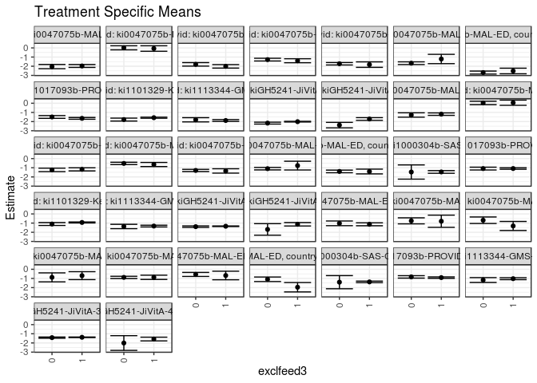

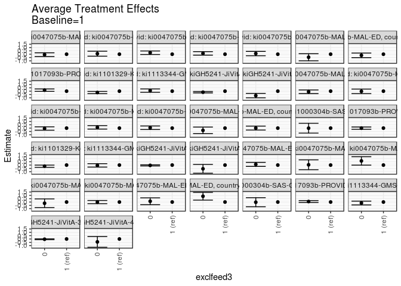

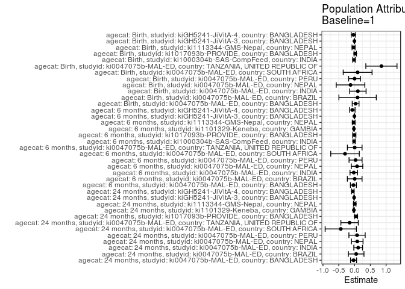

## Results Table

### Parameter: TSM

| agecat | studyid | country | intervention_level | baseline_level | estimate | ci_lower | ci_upper |
| --- | --- | --- | --- | --- | --- | --- | --- |
| Birth | ki0047075b-MAL-ED | BANGLADESH | 1 | NA | -1.1290419 | -1.2903919 | -0.9676918 |
| Birth | ki0047075b-MAL-ED | BANGLADESH | 0 | NA | -1.0262900 | -1.2800692 | -0.7725109 |
| Birth | ki0047075b-MAL-ED | BRAZIL | 1 | NA | -0.7962762 | -1.4592838 | -0.1332686 |
| Birth | ki0047075b-MAL-ED | BRAZIL | 0 | NA | -0.7546316 | -1.0847454 | -0.4245177 |
| Birth | ki0047075b-MAL-ED | INDIA | 1 | NA | -1.3132694 | -1.8064029 | -0.8201359 |
| Birth | ki0047075b-MAL-ED | INDIA | 0 | NA | -0.6886395 | -1.0443874 | -0.3328916 |
| Birth | ki0047075b-MAL-ED | NEPAL | 1 | NA | -0.6962500 | -1.1273498 | -0.2651502 |
| Birth | ki0047075b-MAL-ED | NEPAL | 0 | NA | -0.8800000 | -1.3706027 | -0.3893973 |
| Birth | ki0047075b-MAL-ED | PERU | 1 | NA | -0.8761652 | -1.1070970 | -0.6452335 |
| Birth | ki0047075b-MAL-ED | PERU | 0 | NA | -0.8852361 | -1.0096214 | -0.7608508 |
| Birth | ki0047075b-MAL-ED | SOUTH AFRICA | 1 | NA | -0.6776079 | -1.1439077 | -0.2113081 |
| Birth | ki0047075b-MAL-ED | SOUTH AFRICA | 0 | NA | -0.5611878 | -0.7797423 | -0.3426333 |
| Birth | ki0047075b-MAL-ED | TANZANIA, UNITED REPUBLIC OF | 1 | NA | -1.9597945 | -2.4724098 | -1.4471793 |
| Birth | ki0047075b-MAL-ED | TANZANIA, UNITED REPUBLIC OF | 0 | NA | -1.0906739 | -1.3356647 | -0.8456832 |
| Birth | ki1000304b-SAS-CompFeed | INDIA | 1 | NA | -1.3774344 | -1.4632073 | -1.2916615 |
| Birth | ki1000304b-SAS-CompFeed | INDIA | 0 | NA | -1.4059668 | -2.1227838 | -0.6891497 |
| Birth | ki1017093b-PROVIDE | BANGLADESH | 1 | NA | -0.9065683 | -0.9867390 | -0.8263976 |
| Birth | ki1017093b-PROVIDE | BANGLADESH | 0 | NA | -0.8308083 | -0.9631284 | -0.6984882 |
| Birth | ki1113344-GMS-Nepal | NEPAL | 1 | NA | -1.0245220 | -1.1314296 | -0.9176144 |
| Birth | ki1113344-GMS-Nepal | NEPAL | 0 | NA | -1.1742343 | -1.4393918 | -0.9090768 |
| Birth | kiGH5241-JiVitA-3 | BANGLADESH | 1 | NA | -1.3806114 | -1.4067485 | -1.3544743 |
| Birth | kiGH5241-JiVitA-3 | BANGLADESH | 0 | NA | -1.4187856 | -1.4820341 | -1.3555372 |
| Birth | kiGH5241-JiVitA-4 | BANGLADESH | 1 | NA | -1.5727404 | -1.7750443 | -1.3704365 |
| Birth | kiGH5241-JiVitA-4 | BANGLADESH | 0 | NA | -2.0075420 | -2.8096622 | -1.2054218 |
| 6 months | ki0047075b-MAL-ED | BANGLADESH | 1 | NA | -1.1886402 | -1.3220651 | -1.0552152 |
| 6 months | ki0047075b-MAL-ED | BANGLADESH | 0 | NA | -1.2796194 | -1.5186239 | -1.0406148 |
| 6 months | ki0047075b-MAL-ED | BRAZIL | 1 | NA | 0.0585833 | -0.2222096 | 0.3393762 |
| 6 months | ki0047075b-MAL-ED | BRAZIL | 0 | NA | 0.0318225 | -0.1568728 | 0.2205179 |
| 6 months | ki0047075b-MAL-ED | INDIA | 1 | NA | -1.1754261 | -1.3448520 | -1.0060002 |
| 6 months | ki0047075b-MAL-ED | INDIA | 0 | NA | -1.2342759 | -1.4238830 | -1.0446687 |
| 6 months | ki0047075b-MAL-ED | NEPAL | 1 | NA | -0.6427951 | -0.8681607 | -0.4174295 |
| 6 months | ki0047075b-MAL-ED | NEPAL | 0 | NA | -0.5282208 | -0.6580218 | -0.3984198 |
| 6 months | ki0047075b-MAL-ED | PERU | 1 | NA | -1.3481301 | -1.5848535 | -1.1114067 |
| 6 months | ki0047075b-MAL-ED | PERU | 0 | NA | -1.2935795 | -1.4146560 | -1.1725030 |
| 6 months | ki0047075b-MAL-ED | SOUTH AFRICA | 1 | NA | -0.7648306 | -1.2415844 | -0.2880768 |
| 6 months | ki0047075b-MAL-ED | SOUTH AFRICA | 0 | NA | -1.0990729 | -1.2342857 | -0.9638601 |
| 6 months | ki0047075b-MAL-ED | TANZANIA, UNITED REPUBLIC OF | 1 | NA | -1.4091576 | -1.6692005 | -1.1491148 |
| 6 months | ki0047075b-MAL-ED | TANZANIA, UNITED REPUBLIC OF | 0 | NA | -1.4013408 | -1.5453522 | -1.2573293 |
| 6 months | ki1000304b-SAS-CompFeed | INDIA | 1 | NA | -1.4549959 | -1.6008850 | -1.3091069 |
| 6 months | ki1000304b-SAS-CompFeed | INDIA | 0 | NA | -1.4654856 | -2.2428805 | -0.6880907 |
| 6 months | ki1017093b-PROVIDE | BANGLADESH | 1 | NA | -1.0839752 | -1.1677776 | -1.0001728 |
| 6 months | ki1017093b-PROVIDE | BANGLADESH | 0 | NA | -1.0899983 | -1.2432040 | -0.9367925 |
| 6 months | ki1101329-Keneba | GAMBIA | 1 | NA | -0.9290703 | -0.9831548 | -0.8749859 |
| 6 months | ki1101329-Keneba | GAMBIA | 0 | NA | -1.1013110 | -1.2599768 | -0.9426452 |
| 6 months | ki1113344-GMS-Nepal | NEPAL | 1 | NA | -1.3229809 | -1.4179715 | -1.2279903 |
| 6 months | ki1113344-GMS-Nepal | NEPAL | 0 | NA | -1.3687003 | -1.6046231 | -1.1327774 |
| 6 months | kiGH5241-JiVitA-3 | BANGLADESH | 1 | NA | -1.3425032 | -1.3716224 | -1.3133840 |
| 6 months | kiGH5241-JiVitA-3 | BANGLADESH | 0 | NA | -1.3890299 | -1.4739388 | -1.3041211 |
| 6 months | kiGH5241-JiVitA-4 | BANGLADESH | 1 | NA | -1.1299999 | -1.3181334 | -0.9418665 |
| 6 months | kiGH5241-JiVitA-4 | BANGLADESH | 0 | NA | -1.6897499 | -2.3183912 | -1.0611086 |
| 24 months | ki0047075b-MAL-ED | BANGLADESH | 1 | NA | -1.9707183 | -2.1273516 | -1.8140851 |
| 24 months | ki0047075b-MAL-ED | BANGLADESH | 0 | NA | -2.0387530 | -2.2697872 | -1.8077187 |
| 24 months | ki0047075b-MAL-ED | BRAZIL | 1 | NA | -0.0671050 | -0.3670832 | 0.2328731 |
| 24 months | ki0047075b-MAL-ED | BRAZIL | 0 | NA | 0.0096054 | -0.2112205 | 0.2304312 |
| 24 months | ki0047075b-MAL-ED | INDIA | 1 | NA | -2.0128729 | -2.2024682 | -1.8232776 |
| 24 months | ki0047075b-MAL-ED | INDIA | 0 | NA | -1.7942106 | -1.9846236 | -1.6037976 |
| 24 months | ki0047075b-MAL-ED | NEPAL | 1 | NA | -1.4012202 | -1.6175132 | -1.1849272 |
| 24 months | ki0047075b-MAL-ED | NEPAL | 0 | NA | -1.2799625 | -1.4271736 | -1.1327513 |
| 24 months | ki0047075b-MAL-ED | PERU | 1 | NA | -1.8224285 | -2.1219587 | -1.5228983 |
| 24 months | ki0047075b-MAL-ED | PERU | 0 | NA | -1.7280966 | -1.8610558 | -1.5951375 |
| 24 months | ki0047075b-MAL-ED | SOUTH AFRICA | 1 | NA | -1.2106123 | -1.7190708 | -0.7021538 |
| 24 months | ki0047075b-MAL-ED | SOUTH AFRICA | 0 | NA | -1.6681409 | -1.8147649 | -1.5215169 |
| 24 months | ki0047075b-MAL-ED | TANZANIA, UNITED REPUBLIC OF | 1 | NA | -2.5192918 | -2.8236817 | -2.2149018 |
| 24 months | ki0047075b-MAL-ED | TANZANIA, UNITED REPUBLIC OF | 0 | NA | -2.6914532 | -2.8551333 | -2.5277730 |
| 24 months | ki1017093b-PROVIDE | BANGLADESH | 1 | NA | -1.6469802 | -1.7444489 | -1.5495114 |
| 24 months | ki1017093b-PROVIDE | BANGLADESH | 0 | NA | -1.4952494 | -1.6471670 | -1.3433318 |
| 24 months | ki1101329-Keneba | GAMBIA | 1 | NA | -1.5751861 | -1.6319510 | -1.5184212 |
| 24 months | ki1101329-Keneba | GAMBIA | 0 | NA | -1.7816263 | -1.9424893 | -1.6207633 |
| 24 months | ki1113344-GMS-Nepal | NEPAL | 1 | NA | -1.8820111 | -1.9834999 | -1.7805222 |
| 24 months | ki1113344-GMS-Nepal | NEPAL | 0 | NA | -1.8029001 | -2.0332887 | -1.5725115 |
| 24 months | kiGH5241-JiVitA-3 | BANGLADESH | 1 | NA | -2.0102868 | -2.0481937 | -1.9723799 |
| 24 months | kiGH5241-JiVitA-3 | BANGLADESH | 0 | NA | -2.1665391 | -2.2712231 | -2.0618550 |
| 24 months | kiGH5241-JiVitA-4 | BANGLADESH | 1 | NA | -1.7184159 | -1.8665511 | -1.5702807 |
| 24 months | kiGH5241-JiVitA-4 | BANGLADESH | 0 | NA | -2.3853068 | -2.6839956 | -2.0866179 |

### Parameter: E(Y)

| agecat | studyid | country | intervention_level | baseline_level | estimate | ci_lower | ci_upper |
| --- | --- | --- | --- | --- | --- | --- | --- |
| Birth | ki0047075b-MAL-ED | BANGLADESH | NA | NA | -1.0949767 | -1.2319917 | -0.9579618 |
| Birth | ki0047075b-MAL-ED | BRAZIL | NA | NA | -0.6996491 | -0.9856018 | -0.4136965 |
| Birth | ki0047075b-MAL-ED | INDIA | NA | NA | -1.2075610 | -1.5261540 | -0.8889679 |
| Birth | ki0047075b-MAL-ED | NEPAL | NA | NA | -0.8234615 | -1.1896049 | -0.4573182 |
| Birth | ki0047075b-MAL-ED | PERU | NA | NA | -0.8753812 | -0.9932108 | -0.7575515 |
| Birth | ki0047075b-MAL-ED | SOUTH AFRICA | NA | NA | -0.5797000 | -0.7788298 | -0.3805702 |
| Birth | ki0047075b-MAL-ED | TANZANIA, UNITED REPUBLIC OF | NA | NA | -1.1086275 | -1.3310338 | -0.8862211 |
| Birth | ki1000304b-SAS-CompFeed | INDIA | NA | NA | -1.3937088 | -1.5095039 | -1.2779137 |
| Birth | ki1017093b-PROVIDE | BANGLADESH | NA | NA | -0.8851020 | -0.9601332 | -0.8100709 |
| Birth | ki1113344-GMS-Nepal | NEPAL | NA | NA | -1.0555240 | -1.1550843 | -0.9559638 |
| Birth | kiGH5241-JiVitA-3 | BANGLADESH | NA | NA | -1.3843216 | -1.4102231 | -1.3584201 |
| Birth | kiGH5241-JiVitA-4 | BANGLADESH | NA | NA | -1.6073276 | -1.8105798 | -1.4040753 |
| 6 months | ki0047075b-MAL-ED | BANGLADESH | NA | NA | -1.2248069 | -1.3446487 | -1.1049651 |
| 6 months | ki0047075b-MAL-ED | BRAZIL | NA | NA | 0.0641266 | -0.0913400 | 0.2195931 |
| 6 months | ki0047075b-MAL-ED | INDIA | NA | NA | -1.2002063 | -1.3275718 | -1.0728409 |
| 6 months | ki0047075b-MAL-ED | NEPAL | NA | NA | -0.5628634 | -0.6765658 | -0.4491611 |
| 6 months | ki0047075b-MAL-ED | PERU | NA | NA | -1.3153519 | -1.4229629 | -1.2077408 |
| 6 months | ki0047075b-MAL-ED | SOUTH AFRICA | NA | NA | -1.0665369 | -1.1970117 | -0.9360620 |
| 6 months | ki0047075b-MAL-ED | TANZANIA, UNITED REPUBLIC OF | NA | NA | -1.4030503 | -1.5292443 | -1.2768563 |
| 6 months | ki1000304b-SAS-CompFeed | INDIA | NA | NA | -1.4697236 | -1.6333919 | -1.3060553 |
| 6 months | ki1017093b-PROVIDE | BANGLADESH | NA | NA | -1.0916915 | -1.1661176 | -1.0172654 |
| 6 months | ki1101329-Keneba | GAMBIA | NA | NA | -0.9489317 | -1.0001696 | -0.8976937 |
| 6 months | ki1113344-GMS-Nepal | NEPAL | NA | NA | -1.3499849 | -1.4387386 | -1.2612312 |
| 6 months | kiGH5241-JiVitA-3 | BANGLADESH | NA | NA | -1.3470624 | -1.3756620 | -1.3184628 |
| 6 months | kiGH5241-JiVitA-4 | BANGLADESH | NA | NA | -1.1994318 | -1.3808291 | -1.0180345 |
| 24 months | ki0047075b-MAL-ED | BANGLADESH | NA | NA | -2.0021951 | -2.1308572 | -1.8735330 |
| 24 months | ki0047075b-MAL-ED | BRAZIL | NA | NA | -0.0151974 | -0.1917967 | 0.1614019 |
| 24 months | ki0047075b-MAL-ED | INDIA | NA | NA | -1.8978960 | -2.0332143 | -1.7625777 |
| 24 months | ki0047075b-MAL-ED | NEPAL | NA | NA | -1.3153636 | -1.4359803 | -1.1947469 |
| 24 months | ki0047075b-MAL-ED | PERU | NA | NA | -1.7432323 | -1.8646545 | -1.6218102 |
| 24 months | ki0047075b-MAL-ED | SOUTH AFRICA | NA | NA | -1.6467544 | -1.7856657 | -1.5078431 |
| 24 months | ki0047075b-MAL-ED | TANZANIA, UNITED REPUBLIC OF | NA | NA | -2.6763587 | -2.8207363 | -2.5319811 |
| 24 months | ki1017093b-PROVIDE | BANGLADESH | NA | NA | -1.6024221 | -1.6857420 | -1.5191023 |
| 24 months | ki1101329-Keneba | GAMBIA | NA | NA | -1.5961170 | -1.6505261 | -1.5417080 |
| 24 months | ki1113344-GMS-Nepal | NEPAL | NA | NA | -1.8752995 | -1.9688053 | -1.7817937 |
| 24 months | kiGH5241-JiVitA-3 | BANGLADESH | NA | NA | -2.0239144 | -2.0607740 | -1.9870548 |
| 24 months | kiGH5241-JiVitA-4 | BANGLADESH | NA | NA | -1.7726490 | -1.9111913 | -1.6341067 |

### Parameter: ATE

| agecat | studyid | country | intervention_level | baseline_level | estimate | ci_lower | ci_upper |
| --- | --- | --- | --- | --- | --- | --- | --- |
| Birth | ki0047075b-MAL-ED | BANGLADESH | 1 | 1 | 0.0000000 | 0.0000000 | 0.0000000 |
| Birth | ki0047075b-MAL-ED | BANGLADESH | 0 | 1 | 0.1027518 | -0.1982667 | 0.4037704 |
| Birth | ki0047075b-MAL-ED | BRAZIL | 1 | 1 | 0.0000000 | 0.0000000 | 0.0000000 |
| Birth | ki0047075b-MAL-ED | BRAZIL | 0 | 1 | 0.0416446 | -0.6975336 | 0.7808229 |
| Birth | ki0047075b-MAL-ED | INDIA | 1 | 1 | 0.0000000 | 0.0000000 | 0.0000000 |
| Birth | ki0047075b-MAL-ED | INDIA | 0 | 1 | 0.6246300 | -0.0078782 | 1.2571381 |
| Birth | ki0047075b-MAL-ED | NEPAL | 1 | 1 | 0.0000000 | 0.0000000 | 0.0000000 |
| Birth | ki0047075b-MAL-ED | NEPAL | 0 | 1 | -0.1837500 | -0.8368488 | 0.4693488 |
| Birth | ki0047075b-MAL-ED | PERU | 1 | 1 | 0.0000000 | 0.0000000 | 0.0000000 |
| Birth | ki0047075b-MAL-ED | PERU | 0 | 1 | -0.0090708 | -0.2480208 | 0.2298791 |
| Birth | ki0047075b-MAL-ED | SOUTH AFRICA | 1 | 1 | 0.0000000 | 0.0000000 | 0.0000000 |
| Birth | ki0047075b-MAL-ED | SOUTH AFRICA | 0 | 1 | 0.1164201 | -0.3990388 | 0.6318790 |
| Birth | ki0047075b-MAL-ED | TANZANIA, UNITED REPUBLIC OF | 1 | 1 | 0.0000000 | 0.0000000 | 0.0000000 |
| Birth | ki0047075b-MAL-ED | TANZANIA, UNITED REPUBLIC OF | 0 | 1 | 0.8691206 | 0.2916438 | 1.4465974 |
| Birth | ki1000304b-SAS-CompFeed | INDIA | 1 | 1 | 0.0000000 | 0.0000000 | 0.0000000 |
| Birth | ki1000304b-SAS-CompFeed | INDIA | 0 | 1 | -0.0285323 | -0.7102536 | 0.6531889 |
| Birth | ki1017093b-PROVIDE | BANGLADESH | 1 | 1 | 0.0000000 | 0.0000000 | 0.0000000 |
| Birth | ki1017093b-PROVIDE | BANGLADESH | 0 | 1 | 0.0757600 | -0.0627856 | 0.2143056 |
| Birth | ki1113344-GMS-Nepal | NEPAL | 1 | 1 | 0.0000000 | 0.0000000 | 0.0000000 |
| Birth | ki1113344-GMS-Nepal | NEPAL | 0 | 1 | -0.1497123 | -0.4357813 | 0.1363567 |
| Birth | kiGH5241-JiVitA-3 | BANGLADESH | 1 | 1 | 0.0000000 | 0.0000000 | 0.0000000 |
| Birth | kiGH5241-JiVitA-3 | BANGLADESH | 0 | 1 | -0.0381742 | -0.0996630 | 0.0233145 |
| Birth | kiGH5241-JiVitA-4 | BANGLADESH | 1 | 1 | 0.0000000 | 0.0000000 | 0.0000000 |
| Birth | kiGH5241-JiVitA-4 | BANGLADESH | 0 | 1 | -0.4348016 | -1.2419119 | 0.3723088 |
| 6 months | ki0047075b-MAL-ED | BANGLADESH | 1 | 1 | 0.0000000 | 0.0000000 | 0.0000000 |
| 6 months | ki0047075b-MAL-ED | BANGLADESH | 0 | 1 | -0.0909792 | -0.3650477 | 0.1830893 |
| 6 months | ki0047075b-MAL-ED | BRAZIL | 1 | 1 | 0.0000000 | 0.0000000 | 0.0000000 |
| 6 months | ki0047075b-MAL-ED | BRAZIL | 0 | 1 | -0.0267608 | -0.3671745 | 0.3136530 |
| 6 months | ki0047075b-MAL-ED | INDIA | 1 | 1 | 0.0000000 | 0.0000000 | 0.0000000 |
| 6 months | ki0047075b-MAL-ED | INDIA | 0 | 1 | -0.0588498 | -0.3135114 | 0.1958118 |
| 6 months | ki0047075b-MAL-ED | NEPAL | 1 | 1 | 0.0000000 | 0.0000000 | 0.0000000 |
| 6 months | ki0047075b-MAL-ED | NEPAL | 0 | 1 | 0.1145743 | -0.1459667 | 0.3751154 |
| 6 months | ki0047075b-MAL-ED | PERU | 1 | 1 | 0.0000000 | 0.0000000 | 0.0000000 |
| 6 months | ki0047075b-MAL-ED | PERU | 0 | 1 | 0.0545506 | -0.2118183 | 0.3209195 |
| 6 months | ki0047075b-MAL-ED | SOUTH AFRICA | 1 | 1 | 0.0000000 | 0.0000000 | 0.0000000 |
| 6 months | ki0047075b-MAL-ED | SOUTH AFRICA | 0 | 1 | -0.3342423 | -0.8299718 | 0.1614872 |
| 6 months | ki0047075b-MAL-ED | TANZANIA, UNITED REPUBLIC OF | 1 | 1 | 0.0000000 | 0.0000000 | 0.0000000 |
| 6 months | ki0047075b-MAL-ED | TANZANIA, UNITED REPUBLIC OF | 0 | 1 | 0.0078169 | -0.2867982 | 0.3024319 |
| 6 months | ki1000304b-SAS-CompFeed | INDIA | 1 | 1 | 0.0000000 | 0.0000000 | 0.0000000 |
| 6 months | ki1000304b-SAS-CompFeed | INDIA | 0 | 1 | -0.0104897 | -0.7471588 | 0.7261794 |
| 6 months | ki1017093b-PROVIDE | BANGLADESH | 1 | 1 | 0.0000000 | 0.0000000 | 0.0000000 |
| 6 months | ki1017093b-PROVIDE | BANGLADESH | 0 | 1 | -0.0060230 | -0.1806249 | 0.1685788 |
| 6 months | ki1101329-Keneba | GAMBIA | 1 | 1 | 0.0000000 | 0.0000000 | 0.0000000 |
| 6 months | ki1101329-Keneba | GAMBIA | 0 | 1 | -0.1722407 | -0.3396982 | -0.0047832 |
| 6 months | ki1113344-GMS-Nepal | NEPAL | 1 | 1 | 0.0000000 | 0.0000000 | 0.0000000 |
| 6 months | ki1113344-GMS-Nepal | NEPAL | 0 | 1 | -0.0457194 | -0.3005340 | 0.2090953 |
| 6 months | kiGH5241-JiVitA-3 | BANGLADESH | 1 | 1 | 0.0000000 | 0.0000000 | 0.0000000 |
| 6 months | kiGH5241-JiVitA-3 | BANGLADESH | 0 | 1 | -0.0465268 | -0.1322671 | 0.0392136 |
| 6 months | kiGH5241-JiVitA-4 | BANGLADESH | 1 | 1 | 0.0000000 | 0.0000000 | 0.0000000 |
| 6 months | kiGH5241-JiVitA-4 | BANGLADESH | 0 | 1 | -0.5597500 | -1.2166337 | 0.0971337 |
| 24 months | ki0047075b-MAL-ED | BANGLADESH | 1 | 1 | 0.0000000 | 0.0000000 | 0.0000000 |
| 24 months | ki0047075b-MAL-ED | BANGLADESH | 0 | 1 | -0.0680346 | -0.3483300 | 0.2122608 |
| 24 months | ki0047075b-MAL-ED | BRAZIL | 1 | 1 | 0.0000000 | 0.0000000 | 0.0000000 |
| 24 months | ki0047075b-MAL-ED | BRAZIL | 0 | 1 | 0.0767104 | -0.2968312 | 0.4502521 |
| 24 months | ki0047075b-MAL-ED | INDIA | 1 | 1 | 0.0000000 | 0.0000000 | 0.0000000 |
| 24 months | ki0047075b-MAL-ED | INDIA | 0 | 1 | 0.2186623 | -0.0470291 | 0.4843536 |
| 24 months | ki0047075b-MAL-ED | NEPAL | 1 | 1 | 0.0000000 | 0.0000000 | 0.0000000 |
| 24 months | ki0047075b-MAL-ED | NEPAL | 0 | 1 | 0.1212577 | -0.1400224 | 0.3825379 |
| 24 months | ki0047075b-MAL-ED | PERU | 1 | 1 | 0.0000000 | 0.0000000 | 0.0000000 |
| 24 months | ki0047075b-MAL-ED | PERU | 0 | 1 | 0.0943318 | -0.2327813 | 0.4214450 |
| 24 months | ki0047075b-MAL-ED | SOUTH AFRICA | 1 | 1 | 0.0000000 | 0.0000000 | 0.0000000 |
| 24 months | ki0047075b-MAL-ED | SOUTH AFRICA | 0 | 1 | -0.4575286 | -0.9903967 | 0.0753395 |
| 24 months | ki0047075b-MAL-ED | TANZANIA, UNITED REPUBLIC OF | 1 | 1 | 0.0000000 | 0.0000000 | 0.0000000 |
| 24 months | ki0047075b-MAL-ED | TANZANIA, UNITED REPUBLIC OF | 0 | 1 | -0.1721614 | -0.5166380 | 0.1723153 |
| 24 months | ki1017093b-PROVIDE | BANGLADESH | 1 | 1 | 0.0000000 | 0.0000000 | 0.0000000 |
| 24 months | ki1017093b-PROVIDE | BANGLADESH | 0 | 1 | 0.1517307 | -0.0261502 | 0.3296117 |
| 24 months | ki1101329-Keneba | GAMBIA | 1 | 1 | 0.0000000 | 0.0000000 | 0.0000000 |
| 24 months | ki1101329-Keneba | GAMBIA | 0 | 1 | -0.2064402 | -0.3740264 | -0.0388540 |
| 24 months | ki1113344-GMS-Nepal | NEPAL | 1 | 1 | 0.0000000 | 0.0000000 | 0.0000000 |
| 24 months | ki1113344-GMS-Nepal | NEPAL | 0 | 1 | 0.0791109 | -0.1704986 | 0.3287205 |
| 24 months | kiGH5241-JiVitA-3 | BANGLADESH | 1 | 1 | 0.0000000 | 0.0000000 | 0.0000000 |
| 24 months | kiGH5241-JiVitA-3 | BANGLADESH | 0 | 1 | -0.1562523 | -0.2636899 | -0.0488147 |
| 24 months | kiGH5241-JiVitA-4 | BANGLADESH | 1 | 1 | 0.0000000 | 0.0000000 | 0.0000000 |
| 24 months | kiGH5241-JiVitA-4 | BANGLADESH | 0 | 1 | -0.6668908 | -1.0003856 | -0.3333961 |

### Parameter: PAR

| agecat | studyid | country | intervention_level | baseline_level | estimate | ci_lower | ci_upper |
| --- | --- | --- | --- | --- | --- | --- | --- |
| Birth | ki0047075b-MAL-ED | BANGLADESH | 1 | NA | 0.0340651 | -0.0736624 | 0.1417926 |
| Birth | ki0047075b-MAL-ED | BRAZIL | 1 | NA | 0.0966271 | -0.4953128 | 0.6885669 |
| Birth | ki0047075b-MAL-ED | INDIA | 1 | NA | 0.1057085 | -0.1539688 | 0.3653857 |
| Birth | ki0047075b-MAL-ED | NEPAL | 1 | NA | -0.1272115 | -0.5805774 | 0.3261543 |
| Birth | ki0047075b-MAL-ED | PERU | 1 | NA | 0.0007841 | -0.1868274 | 0.1883955 |
| Birth | ki0047075b-MAL-ED | SOUTH AFRICA | 1 | NA | 0.0979079 | -0.3591582 | 0.5549740 |
| Birth | ki0047075b-MAL-ED | TANZANIA, UNITED REPUBLIC OF | 1 | NA | 0.8511671 | 0.3574788 | 1.3448553 |
| Birth | ki1000304b-SAS-CompFeed | INDIA | 1 | NA | -0.0162744 | -0.0566088 | 0.0240600 |
| Birth | ki1017093b-PROVIDE | BANGLADESH | 1 | NA | 0.0214663 | -0.0174504 | 0.0603830 |
| Birth | ki1113344-GMS-Nepal | NEPAL | 1 | NA | -0.0310021 | -0.0797587 | 0.0177546 |
| Birth | kiGH5241-JiVitA-3 | BANGLADESH | 1 | NA | -0.0037102 | -0.0094358 | 0.0020154 |
| Birth | kiGH5241-JiVitA-4 | BANGLADESH | 1 | NA | -0.0345872 | -0.1061098 | 0.0369355 |
| 6 months | ki0047075b-MAL-ED | BANGLADESH | 1 | NA | -0.0361667 | -0.1311072 | 0.0587738 |
| 6 months | ki0047075b-MAL-ED | BRAZIL | 1 | NA | 0.0055433 | -0.2270153 | 0.2381018 |
| 6 months | ki0047075b-MAL-ED | INDIA | 1 | NA | -0.0247803 | -0.1438590 | 0.0942985 |
| 6 months | ki0047075b-MAL-ED | NEPAL | 1 | NA | 0.0799317 | -0.1014242 | 0.2612876 |
| 6 months | ki0047075b-MAL-ED | PERU | 1 | NA | 0.0327782 | -0.1737985 | 0.2393550 |
| 6 months | ki0047075b-MAL-ED | SOUTH AFRICA | 1 | NA | -0.3017063 | -0.7537500 | 0.1503374 |
| 6 months | ki0047075b-MAL-ED | TANZANIA, UNITED REPUBLIC OF | 1 | NA | 0.0061073 | -0.2260551 | 0.2382697 |
| 6 months | ki1000304b-SAS-CompFeed | INDIA | 1 | NA | -0.0147277 | -0.0507565 | 0.0213012 |
| 6 months | ki1017093b-PROVIDE | BANGLADESH | 1 | NA | -0.0077163 | -0.0589044 | 0.0434718 |
| 6 months | ki1101329-Keneba | GAMBIA | 1 | NA | -0.0198613 | -0.0391724 | -0.0005502 |
| 6 months | ki1113344-GMS-Nepal | NEPAL | 1 | NA | -0.0270040 | -0.0714690 | 0.0174610 |
| 6 months | kiGH5241-JiVitA-3 | BANGLADESH | 1 | NA | -0.0045593 | -0.0120493 | 0.0029307 |
| 6 months | kiGH5241-JiVitA-4 | BANGLADESH | 1 | NA | -0.0694319 | -0.1558893 | 0.0170256 |
| 24 months | ki0047075b-MAL-ED | BANGLADESH | 1 | NA | -0.0314768 | -0.1262509 | 0.0632973 |
| 24 months | ki0047075b-MAL-ED | BRAZIL | 1 | NA | 0.0519077 | -0.1950093 | 0.2988247 |
| 24 months | ki0047075b-MAL-ED | INDIA | 1 | NA | 0.1149769 | -0.0237025 | 0.2536562 |
| 24 months | ki0047075b-MAL-ED | NEPAL | 1 | NA | 0.0858566 | -0.0974638 | 0.2691769 |
| 24 months | ki0047075b-MAL-ED | PERU | 1 | NA | 0.0791962 | -0.1786877 | 0.3370801 |
| 24 months | ki0047075b-MAL-ED | SOUTH AFRICA | 1 | NA | -0.4361421 | -0.9309381 | 0.0586539 |
| 24 months | ki0047075b-MAL-ED | TANZANIA, UNITED REPUBLIC OF | 1 | NA | -0.1570669 | -0.4325252 | 0.1183914 |
| 24 months | ki1017093b-PROVIDE | BANGLADESH | 1 | NA | 0.0445580 | -0.0080105 | 0.0971266 |
| 24 months | ki1101329-Keneba | GAMBIA | 1 | NA | -0.0209309 | -0.0381812 | -0.0036806 |
| 24 months | ki1113344-GMS-Nepal | NEPAL | 1 | NA | 0.0067116 | -0.0333607 | 0.0467838 |
| 24 months | kiGH5241-JiVitA-3 | BANGLADESH | 1 | NA | -0.0136276 | -0.0229879 | -0.0042674 |
| 24 months | kiGH5241-JiVitA-4 | BANGLADESH | 1 | NA | -0.0542331 | -0.0929769 | -0.0154892 |